# DV_FinalProject

ENK

May 11, 2015

Created by: Natasha Halfin, Evan Johnston, and Kaylyn Zvonek

```r
library("bitops")
library("datasets")
library("dplyr")
```

```r
library("ggplot2")
library("ggthemes")
library("gplots")
library("graphics")
library("grDevices")
library("grid")
library("jsonlite")
library("knitr")
library("lubridate")
library("methods")
library("RCurl")
library("reshape2")
library("rmarkdown")
library("rstudio")
library("scales")
library("stats")
library("tidyr")
library("utils")

source("../01 Data/Data.R")
source("../02 Data Wrangling/DataWrangling.R")
source("../03 Visualizations/Visualizations.R")
```

For our project, we chose to work with three datasets. One contains data on the top 5000 companies in the U.S., the second contains state employment data, and the third data set describes housing data by state. Our goal was to cover as much material as possible covered in class, including data blending, data joins, beautiful plotting, data wrangling, SQL crosstabs, and advanced table calculations.

The top companies data is from Inc.com, and the state housing and employment data is from census.gov. All data is for the year 2012. The Oracle tables can be found under Natasha Halfin (UTEID nh5797).

Below is a snapshot of the dataframes for each dataset prior to any data manipulation.

Top Companies Data

```r
data.frame(head(dfTOPCOMPANIES))
```

```
##   COMPANYID STATE                   INDUSTRY   REVENUE GROWTH
## 1       173    NJ                     Health   5400000 11.100
## 2       174    PA                     Health   9500000 11.098
## 3       175    AZ Logistics & Transportation  25400000 11.048
## 4       176    VA        Government Services  39000000 11.029
## 5       177    MA                  Insurance 207700000 10.999
## 6       178    UT                   Software  15500000 10.971
```

State Employment Data

```r
data.frame(head(dfSTATETOTALS))
```

```
##   STATE NUM_FIRMS NUM_ESTABLISHMENTS EMPLOYMENT   PAYROLL
## 1    AL     73661              97938    1585761  61284931
## 2    AK     16656              20427     258219  13986403
## 3    AZ    101205             131375    2134252  90838616
## 4    AR     50412              64815     978519  35633588
## 5    CA    701899             864913   12952818 700102379
## 6    CO    126478             153112    2035803  97691175
```

State Housing Data

```r
data.frame(head(dfSTATEHOUSING))
```

```
##   STATE POPULATION  HOUSING TOTALAREA WATERAREA  LANDAREA
## 1    AL    4779736  2171853  52420.07   1774.74  50645.33
## 2    AK     710231   306967 665384.06  94743.10 570640.94
## 3    AZ    6392017  2844526 113990.30    396.22 113594.08
## 4    AR    2915918  1316299  53178.55   1143.07  52035.48
## 5    CA   37253956 13680081 163694.73   7915.52 155779.22
## 6    CO    5029196  2212898 104093.67    451.78 103641.89
##   POPULATIONDENSITY HOUSINGDENSITY
## 1              94.4           42.9
## 2               1.2            0.5
## 3              56.3           25.0
## 4              56.0           25.3
## 5             239.1           87.8
## 6              48.5           21.4
```

## Data Wranglings

The dataframe below displays a left join between the state employment data and the state housing data based on the key of state. There have also been mutated columns added that represent calculated values based on existing columns, such as Average Employment (AVG_EMP).

```r
data.frame(head(dfSTATEHOUSINGTOTALS))
```

```
##   STATE NUM_FIRMS NUM_ESTABLISHMENTS EMPLOYMENT   PAYROLL POPULATION
## 1    AL     73661              97938    1585761  61284931    4779736
## 2    AK     16656              20427     258219  13986403     710231
## 3    AZ    101205             131375    2134252  90838616    6392017
## 4    AR     50412              64815     978519  35633588    2915918
## 5    CA    701899             864913   12952818 700102379   37253956
## 6    CO    126478             153112    2035803  97691175    5029196
##    HOUSING TOTALAREA WATERAREA  LANDAREA POPULATIONDENSITY HOUSINGDENSITY
## 1  2171853  52420.07   1774.74  50645.33              94.4           42.9
## 2   306967 665384.06  94743.10 570640.94               1.2            0.5
## 3  2844526 113990.30    396.22 113594.08              56.3           25.0
## 4  1316299  53178.55   1143.07  52035.48              56.0           25.3
## 5 13680081 163694.73   7915.52 155779.22             239.1           87.8
## 6  2212898 104093.67    451.78 103641.89              48.5           21.4
##    EMP_RATE  WATER_PERC LAND_PERC  AVG_EMP  AVG_PAY
## 1 0.3317675 0.033856116 0.9661438 16.19148 38.64702
## 2 0.3635704 0.142388595 0.8576114 12.64106 54.16489
## 3 0.3338934 0.003475910 0.9965241 16.24550 42.56227
## 4 0.3355784 0.021494944 0.9785050 15.09711 36.41584
## 5 0.3476897 0.048355373 0.9516447 14.97586 54.05020
## 6 0.4047969 0.004340129 0.9956599 13.29617 47.98656
```

This dataframe displays the Top Companies Data grouped by Industry and State, with summarized values indicating average revenue and growth.

```r
data.frame(head(dfTopCompanies2))
```

```
##                  INDUSTRY STATE AVG_REVENUE AVG_GROWTH
## 1 Advertising & Marketing    AL     3200000   0.422000
## 2 Advertising & Marketing    AR    16050000   2.785000
## 3 Advertising & Marketing    AZ    19558333   1.564167
## 4 Advertising & Marketing    CA  4119204933   3.886627
## 5 Advertising & Marketing    CO    13337500   2.338625
## 6 Advertising & Marketing    CT     9550000   3.001833
```

This dataframe the same combination of Top Companies data as the one above,except it is filtered to only show results for Texas companies and industries.

```r
data.frame(head(dfTopCompanies3))
```

```
##                       INDUSTRY STATE AVG_REVENUE AVG_GROWTH
## 1      Advertising & Marketing    TX    17688462   6.641577
## 2 Business Products & Services    TX    27817143   2.497714
## 3            Computer Hardware    TX    19800000   1.294750
## 4                 Construction    TX    38806452   2.373097
## 5 Consumer Products & Services    TX    24133333   1.518867
## 6                    Education    TX    31700000   1.148200
```

This dataframe is a left join between a dataframe of the Top Companies data, grouped by state, with dfSTATEHOUSINGTOTALS from above. This displays a wide range of industry, employment, and housing data for each state.

```r
data.frame(head(dfTOTALS))
```

```
##   STATE NUM_FIRMS NUM_ESTABLISHMENTS EMPLOYMENT   PAYROLL POPULATION
## 1    AL     73661              97938    1585761  61284931    4779736
## 2    AK     16656              20427     258219  13986403     710231
## 3    AZ    101205             131375    2134252  90838616    6392017
## 4    AR     50412              64815     978519  35633588    2915918
## 5    CA    701899             864913   12952818 700102379   37253956
## 6    CO    126478             153112    2035803  97691175    5029196
##    HOUSING TOTALAREA WATERAREA  LANDAREA POPULATIONDENSITY HOUSINGDENSITY
## 1  2171853  52420.07   1774.74  50645.33              94.4           42.9
## 2   306967 665384.06  94743.10 570640.94               1.2            0.5
## 3  2844526 113990.30    396.22 113594.08              56.3           25.0
## 4  1316299  53178.55   1143.07  52035.48              56.0           25.3
## 5 13680081 163694.73   7915.52 155779.22             239.1           87.8
## 6  2212898 104093.67    451.78 103641.89              48.5           21.4
##    EMP_RATE  WATER_PERC LAND_PERC  AVG_EMP  AVG_PAY   groAvg    revAvg
## 1 0.3317675 0.033856116 0.9661438 16.19148 38.64702 1.845849  49277358
## 2 0.3635704 0.142388595 0.8576114 12.64106 54.16489 2.333000  11300000
## 3 0.3338934 0.003475910 0.9965241 16.24550 42.56227 1.874944  24865741
## 4 0.3355784 0.021494944 0.9785050 15.09711 36.41584 1.278818   8800000
## 5 0.3476897 0.048355373 0.9516447 14.97586 54.05020 3.685453 597559983
## 6 0.4047969 0.004340129 0.9956599 13.29617 47.98656 2.911014  79408163
```

The dataframe below utilizes SQL crosstabs by ranking companies within the Top Companies dataset, when partitioned by industry, and ordered by revenue.

```r
data.frame(head(dfRANKREVENUE))
```

```
##   COMPANYID                INDUSTRY     REVENUE INDUSTRY_RANK
## 1      4664 Advertising & Marketing 3.40549e+11             1
## 2      3033 Advertising & Marketing 3.66100e+08             2
## 3      2754 Advertising & Marketing 2.32600e+08             3
## 4      1871 Advertising & Marketing 2.08900e+08             4
## 5      1430 Advertising & Marketing 2.00900e+08             5
## 6      2010 Advertising & Marketing 1.51400e+08             6
```

This dataframe is another ranking SQL crosstab, this time for the housing dataset. Here, we display the ranking of population density by state.

```r
data.frame(head(dfRANKPOPDENSITY))
```

```
##   STATE POPULATION HOUSING POPULATIONDENSITY POPDENSITY_RANK
## 1    DC     601723  296719            9856.5               1
## 2    NJ    8791894 3553562            1195.5               2
## 3    RI    1052567  463388            1018.1               3
## 4    MA    6547629 2808254             839.4               4
## 5    CT    3574097 1487891             738.1               5
## 6    MD    5773552 2378814             594.8               6
```

## Visualizations in R

The wrangled dataframes from above and others allow for interesting visualizations from the data on companies, housing, and state demographics.

This first visualization shows population by state, where population includes all persons in society. Additionally, it shows the number of housing units, colored by intensity, per state, and land area (*100 for scalar mapping appropriateness) as shown by the squares. This graph demonstrates the non-linear relationship between population, housing, and geographical space.

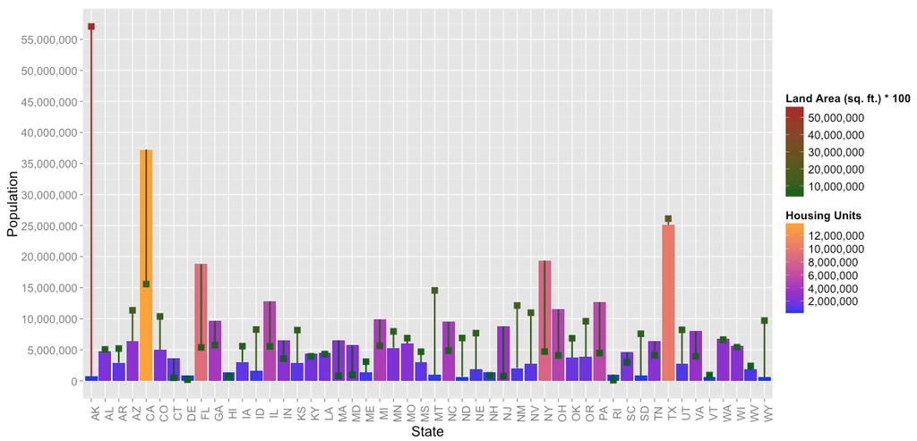

The second visualization attempts to show a relationship between Employment rate and Average Annual pay. Such a relationship should intuitively exist, and be positively correlated. The data do show a positively correlated regression, but much variance can be seen by the spread of the dots. Additionally, this plot shows the number of establishments and population to give the viewer alternate considerations of possible confounding variables.

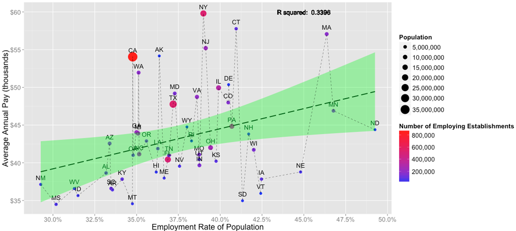

This third visualization converts employment rate, average employment per state, average annual income, and average growth to normalized distributions so they can be simultaneously compared. It is clear that these metrics are mostly normal, all having a mean within 1 standard deviation of each other. Additionally, it can be seen that the average annual pay (in nominal terms) is below the mean farther than other metrics (pay, employment, and growth) which is consistent with current literature suggesting that nominal wages have not caught up to economic growth. Similarly, this could be related to why we have seen increased employment in recent years, yet poverty rates are still higher than normal.

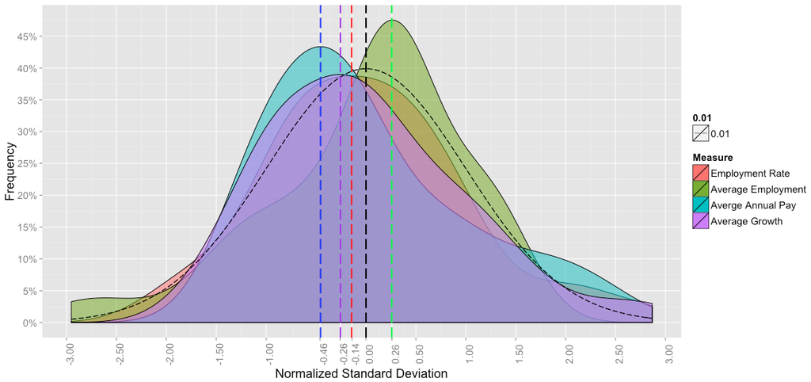

## Tableau Visualizations

Employment rate is a calculated field that finds the average employment rate by state by dividing number of employed people by the population. Pay rate is a calculated field that displays the average annual pay by state. It is found by dividing the total payroll for an entire state by the state’s number of employees. Size displays the pay rate and color displays the employment rate. The database used is a join of the state housing and state totals tables on state.

[figure not shown]

Color shows the state that performs best in a given industries. The text shows a given industries percentile contribution to a state with all the industries in one state adding up to 100%. The data used is from the top companies table.

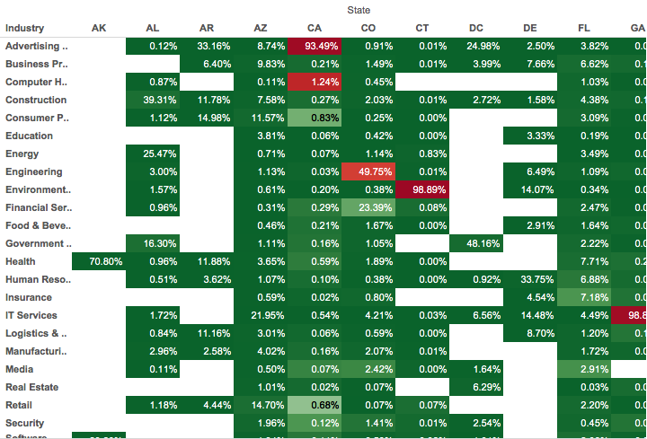

A dual axis is used to show population density on top of a double bar chart displaying land and water proportions by state. The database used is a join of the state housing and state totals tables on state.

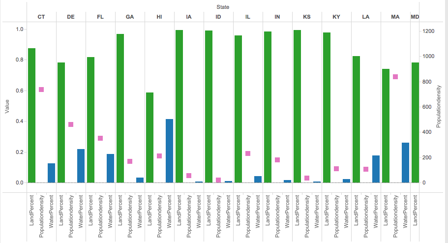

The color shows the total area of a state and the size shows the population of a given state.

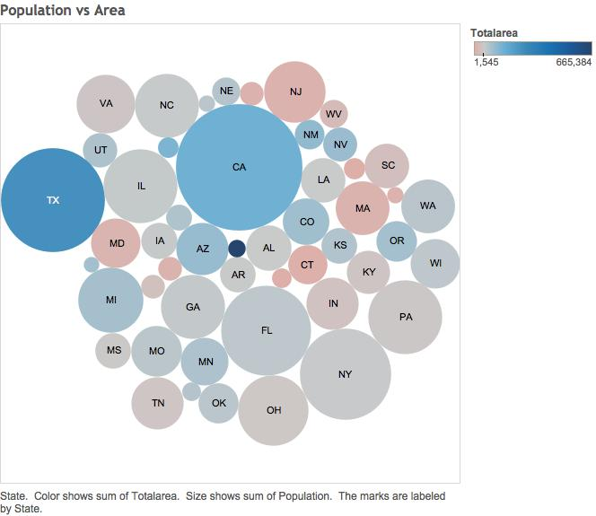

The nth parameter is used to show nth growth by city from unique company ids. The color range reflects the lowest to highest growth over all company ids. The top companies table is used.

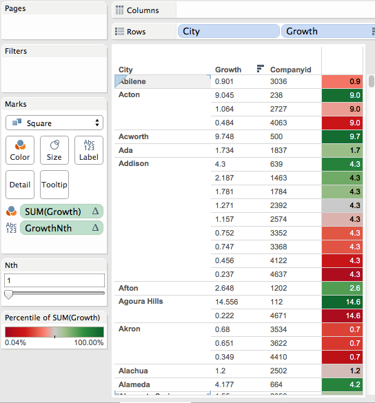